# Landskapsanalys v2.1: Kontextskalekanslighet

> Denna rapport dokumenterar skalkansligheten ovanpa `landskapsanalys_v2_1_geomweight58_res9`, med samma viktlogik men tre olika `k`-stegar.

## 1. Syfte

Denna rapport svarar pa fragan:

**Haller `10, 50, 100, 250, 1000` som arbetssteg, eller blir modellen tydligt battre av en alternativ `k`-stege?**

Testet bygger pa samma `v2.1`-modell, men med tre skalfamiljer:

- `legacy`: `10, 50, 100, 250, 1000`
- `local_geom`: `8, 24, 72, 216, 648`
- `broad_geom`: `15, 45, 135, 405, 1215`

Allt annat halls konstant:

- samma inputlager
- samma viktlogik
- samma `varimax`
- samma `5` faktorer
- samma klusterprovning `K = 5..10`

## 2. Huvudresultat

Local geometric scales ger hogst silhouette (0.348), men legacy-stegen ar fortfarande den starkaste kompromissen nar man vagar samman lokalitet, faktorstruktur och klusterbalans.

| Skalfamilj | Analys-ID | k-varden | Kumulativ varians | Bast K | Bast silhouette | Storsta klustershare | Minsta klustershare | Mean total |
| --- | --- | --- | --- | --- | --- | --- | --- | --- |
| legacy | landskapsanalys_v2_1_geomweight58_res9 | 10,50,100,250,1000 | 36.02% | 6 | 0.312 | 50.9% | 2.8% | 7.34 |
| local_geom | landskapsanalys_v2_1_k_local_geom58_res9 | 8,24,72,216,648 | 33.94% | 6 | 0.348 | 56.1% | 3.4% | 7.34 |
| broad_geom | landskapsanalys_v2_1_k_broad_geom58_res9 | 15,45,135,405,1215 | 37.76% | 5 | 0.299 | 56.2% | 2.8% | 7.34 |

Det finns ingen enkel universell vinnare:

- `local_geom` ger starkast klusterseparation
- `broad_geom` ger hogst forklarad varians
- `legacy` ligger mitt emellan och ar den jamnaste kompromissen

## 3. Klusterbeteende

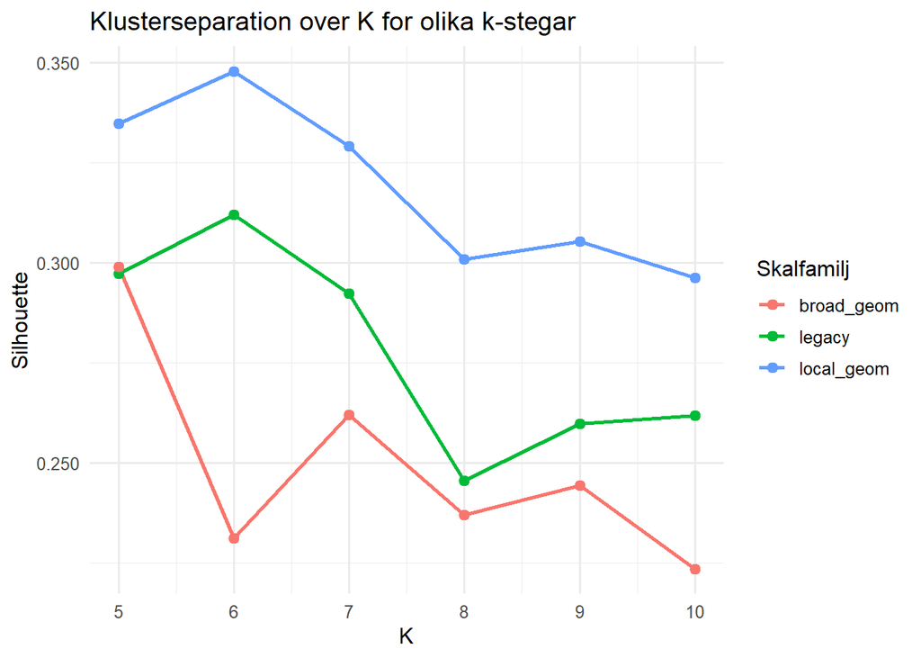

Klustermassigt ar resultaten tydliga:

- `local_geom` -> bast `K = 6`, silhouette `0.348`
- `legacy` -> bast `K = 6`, silhouette `0.312`
- `broad_geom` -> bast `K = 5`, silhouette `0.299`

Det betyder att en mer lokal stege gor modellen mer separerbar i faktorrummet, medan en bredare stege trycker modellen mot mer sammanslagna kluster.

## 4. Kontextlokalitet och radier

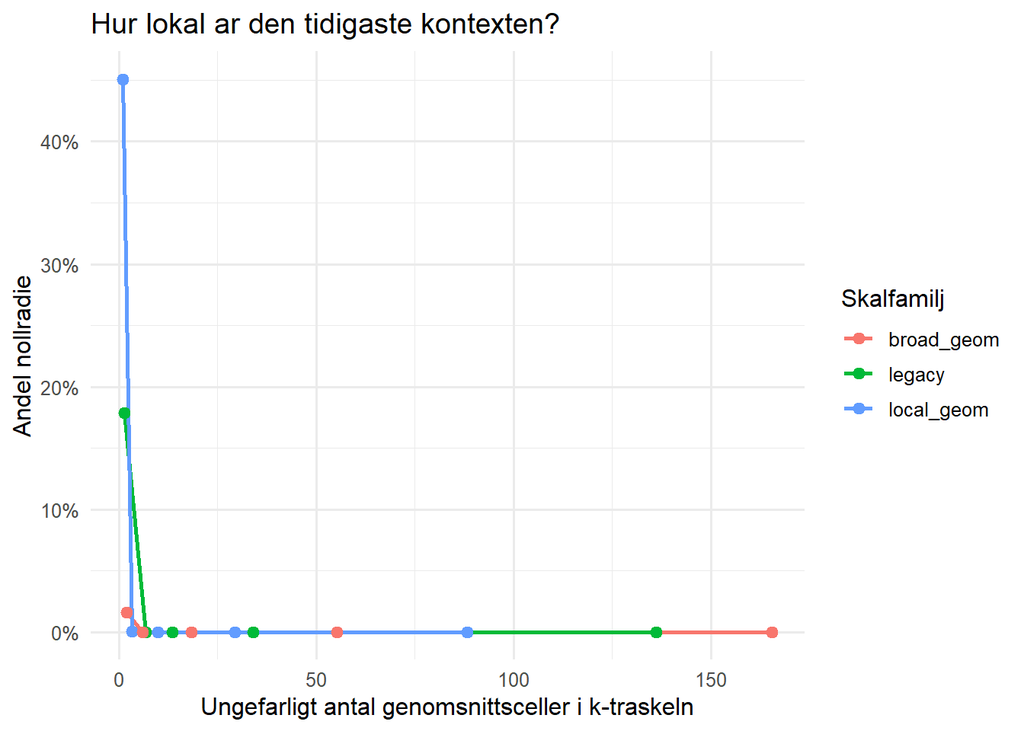

| Skalfamilj | Analys-ID | k | Approx celler | Nollradieandel | Medianradie | P90-radie |
| --- | --- | --- | --- | --- | --- | --- |
| legacy | landskapsanalys_v2_1_geomweight58_res9 | 10 | 1.4 | 17.9% | 306 | 320 |
| legacy | landskapsanalys_v2_1_geomweight58_res9 | 50 | 6.8 | 0.0% | 340 | 613 |
| legacy | landskapsanalys_v2_1_geomweight58_res9 | 100 | 13.6 | 0.0% | 585 | 880 |
| legacy | landskapsanalys_v2_1_geomweight58_res9 | 250 | 34.1 | 0.0% | 918 | 1 434 |
| legacy | landskapsanalys_v2_1_geomweight58_res9 | 1000 | 136.3 | 0.0% | 1 953 | 2 966 |
| local_geom | landskapsanalys_v2_1_k_local_geom58_res9 | 8 | 1.1 | 45.1% | 305 | 306 |
| local_geom | landskapsanalys_v2_1_k_local_geom58_res9 | 24 | 3.3 | 0.1% | 320 | 525 |
| local_geom | landskapsanalys_v2_1_k_local_geom58_res9 | 72 | 9.8 | 0.0% | 561 | 801 |
| local_geom | landskapsanalys_v2_1_k_local_geom58_res9 | 216 | 29.4 | 0.0% | 879 | 1 358 |
| local_geom | landskapsanalys_v2_1_k_local_geom58_res9 | 648 | 88.3 | 0.0% | 1 563 | 2 379 |
| broad_geom | landskapsanalys_v2_1_k_broad_geom58_res9 | 15 | 2.0 | 1.6% | 306 | 320 |
| broad_geom | landskapsanalys_v2_1_k_broad_geom58_res9 | 45 | 6.1 | 0.0% | 340 | 610 |
| broad_geom | landskapsanalys_v2_1_k_broad_geom58_res9 | 135 | 18.4 | 0.0% | 679 | 1 089 |
| broad_geom | landskapsanalys_v2_1_k_broad_geom58_res9 | 405 | 55.2 | 0.0% | 1 205 | 1 858 |
| broad_geom | landskapsanalys_v2_1_k_broad_geom58_res9 | 1215 | 165.5 | 0.0% | 2 142 | 3 314 |

Har ligger den viktigaste metodskillnaden:

- `local_geom` gor den forsta skalan mer verkligt lokal, men ocksa mer sjalvdominerad: `45.1%` nollradie vid `k=8`
- `legacy` ligger mellan ytterligheterna: `17.9%` nollradie vid `k=10`
- `broad_geom` gor den forsta skalan mindre sjalvdominerad: bara `1.6%` nollradie vid `k=15`

Med andra ord:

- `local_geom` far mer lokal kontrast
- `broad_geom` får mer omedelbar omgivningsinblandning
- `legacy` verkar vara en medelvag som fortfarande skiljer lokal och omgivande struktur utan att kollapsa helt at nagot hall

## 5. Faktorstruktur

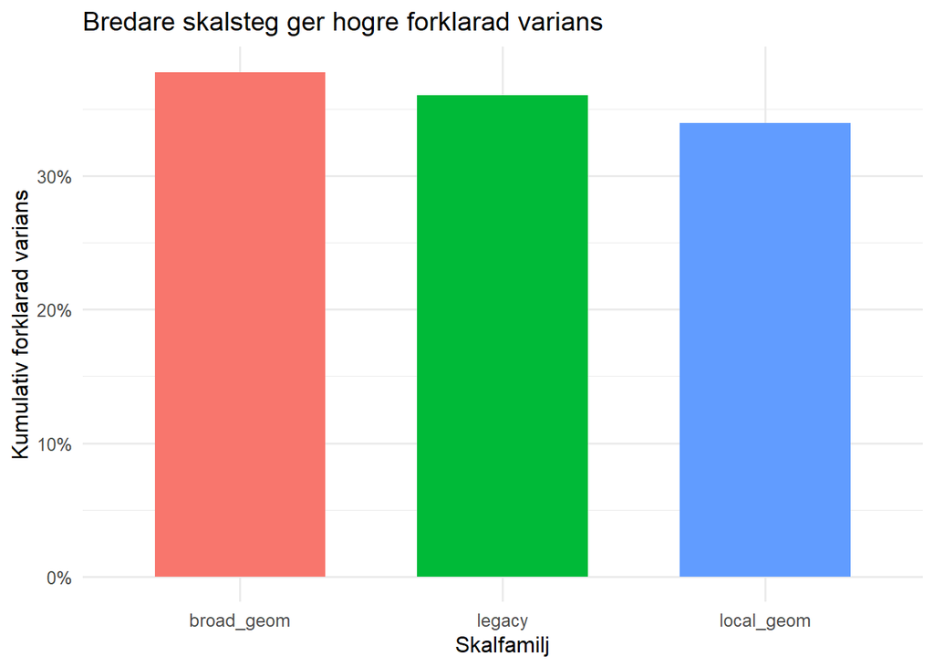

Faktorstrukturen reagerar i motsatt riktning mot klustren:

- `broad_geom`: `37.76%` kumulativ varians
- `legacy`: `36.02%`
- `local_geom`: `33.94%`

Detta ar logiskt. Bredare skalor jamnar ut lokala skillnader och gynnar storre, mer sammanhangande gradienter. Lokalare skalor behaller mer rumslig kontrast men mindre statistisk samvariation.

## 6. Arbetsposition

Min arbetsposition efter detta test ar:

1. Behall `10, 50, 100, 250, 1000` som arbetsstege i `v2.1`.
2. Tolka `local_geom` som den viktiga alternativa challengern om vi senare vill trycka modellen mot mer lokal kontrast.
3. Tolka `broad_geom` som en nyttig kontroll, men inte som basta arbetsval just nu eftersom klusterseparationen blir svagare och modellen glider tillbaka mot `K = 5`.

Det viktigaste skälet att stanna vid legacy just nu ar att den gor inget enskilt moment absolut bast, men den undviker ocksa att bli extrem:

- inte for lokal
- inte for utjamnad
- fortfarande `K = 6`
- fortfarande rimlig faktorvarians
- fortfarande battre klusterbalans an de alternativa stegarna

**Arbetsbeslutet just nu blir darfor: behall `k = 10, 50, 100, 250, 1000` i `v2.1` tills leave-one-theme-out ar kord.**